# Data Exploration and Deterministic Functions

Sarah Guitart

2022-10-06

```r
# Install packages
install.packages("here", repos="http://cran.us.r-project.org")
require(here)
# Create data frame and inspect it
dat_habitat <- read.csv(here("data", "hab.sta.csv"))
str(dat_habitat)
```

```
## 'data.frame':    1046 obs. of  24 variables:
##  $ basin   : chr  "D" "D" "D" "D" ...
##  $ sub     : chr  "AL" "AL" "AL" "AL" ...
##  $ sta     : int  1 2 3 4 5 6 7 8 9 10 ...
##  $ lat     : num  4924418 4924430 4924416 4923998 4923999 ...
##  $ long    : num  437010 437201 437431 437731 437544 ...
##  $ elev    : int  542 519 584 612 580 554 591 616 651 629 ...
##  $ slope   : int  75 80 70 60 43 65 72 28 42 42 ...
##  $ aspect  : int  15 326 230 208 235 60 60 80 70 65 ...
##  $ s.id    : int  3 2 1 3 3 3 3 3 3 3 ...
##  $ s.edge  : chr  "E" "E" "I" "I" ...
##  $ p.edge  : chr  "E" "E" "I" "E" ...
##  $ p.edge.1: int  131 192 0 120 0 166 136 107 0 0 ...
##  $ p.cwedge: int  79 175 0 6 0 8 12 5 0 0 ...
##  $ ba.con  : int  0 18 0 9 14 9 0 5 37 5 ...
##  $ ba.hard : int  5 0 0 14 0 0 5 0 0 0 ...
##  $ ba.snag : int  0 18 5 0 0 5 0 5 0 0 ...
##  $ ba.tot  : int  5 18 0 23 14 9 5 5 37 5 ...
##  $ ba.ratio: int  0 100 50 40 100 100 0 100 100 100 ...
##  $ snag.sml: int  7 67 14 4 0 21 4 11 4 0 ...
##  $ snag.ml : int  4 46 11 4 0 7 4 11 4 0 ...
##  $ snag.l  : int  0 32 4 4 0 7 4 11 4 0 ...
##  $ snag.dc1: int  4 28 0 0 0 7 0 0 0 0 ...
##  $ snag.dc2: int  0 21 4 0 0 0 0 0 0 0 ...
##  $ snag.dc4: int  4 18 11 4 0 14 4 11 4 0 ...
```

```r
head(dat_habitat, 3)
```

```
##   basin sub sta     lat     long elev slope aspect s.id s.edge p.edge p.edge.1
## 1     D  AL   1 4924418 437009.8  542    75     15    3      E      E      131
## 2     D  AL   2 4924430 437200.6  519    80    326    2      E      E      192
## 3     D  AL   3 4924416 437430.8  584    70    230    1      I      I        0
##   p.cwedge ba.con ba.hard ba.snag ba.tot ba.ratio snag.sml snag.ml snag.l
## 1       79      0       5       0      5        0        7       4      0
## 2      175     18       0      18     18      100       67      46     32
## 3        0      0       0       5      0       50       14      11      4
##   snag.dc1 snag.dc2 snag.dc4
## 1        4        0        4
## 2       28       21       18
## 3        0        4       11
```

```r
dim(dat_habitat)
```

```
## [1] 1046   24
```

### Q1

Create histograms for elevation, slope, and aspect within one plot.

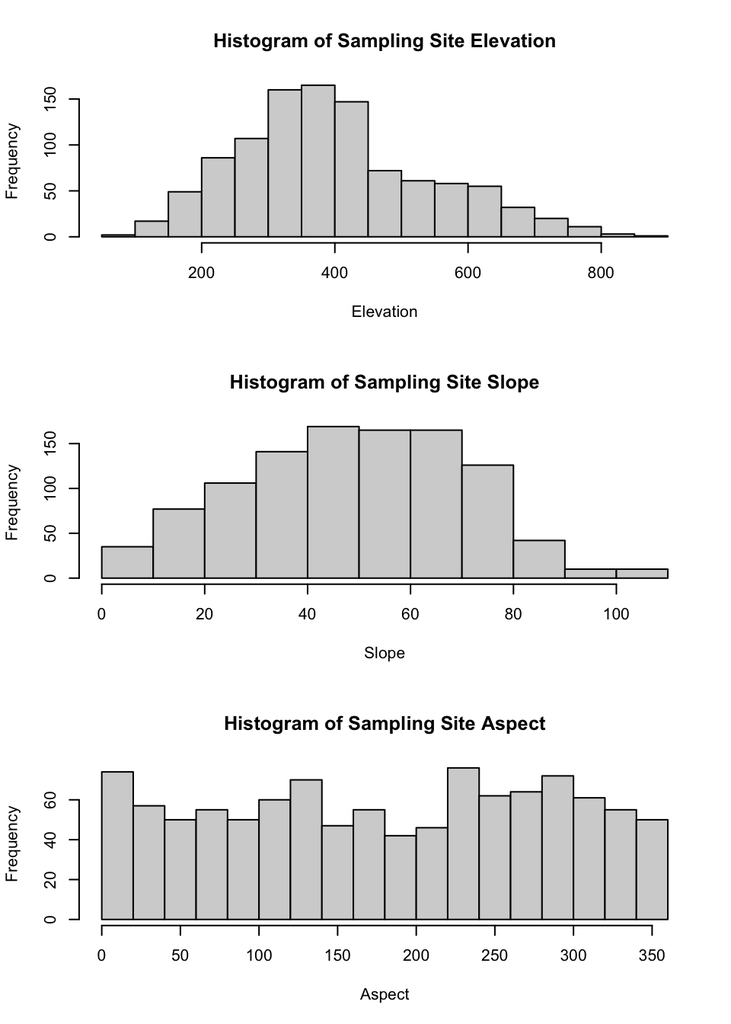

```r
# Create histograms of the three terrain variables in one plot
par(mfrow = c(3, 1))
hist(dat_habitat$elev, main = "Histogram of Sampling Site Elevation",
     xlab = "Elevation")
hist(dat_habitat$slope, main = "Histogram of Sampling Site Slope",
     xlab = "Slope")
hist(dat_habitat$aspect, breaks = 20, main = "Histogram of Sampling Site Aspect",
     xlab = "Aspect")
```

### Q2

**Consider the distribution of elevations at the bird census sample sites.**

The sampling sites within this dataset tend to fall in the mid to lower elevation category. The majority of sites are found at 450 meters in elevation and below, with the most commonly seen elevations falling between 200 and 450 meters. Although there are a few sites above 800 meters, once you exceed 500 meters, the number of sites tends to decrease as you gain elevation.

### Q3

**What are the units of slope in this dataset?**

The units of slope in this dataset are in percent of slope. This is found by dividing the gain in elevation by the horizontal distance covered and multiplying by 100. So sites with 20-30% slope have a gentler incline and sites above 100% slope are incredibly steep.

### Q5

**Briefly define aspect, describing the units used in the dataset.**

Aspect is the direction a slope faces. In this dataset, it is measured in degrees like in a compass. An aspect measurement of 90 degrees would mean an east-facing slope, and a measurement of 270 degrees would mean a west-facing slope.

### Q7

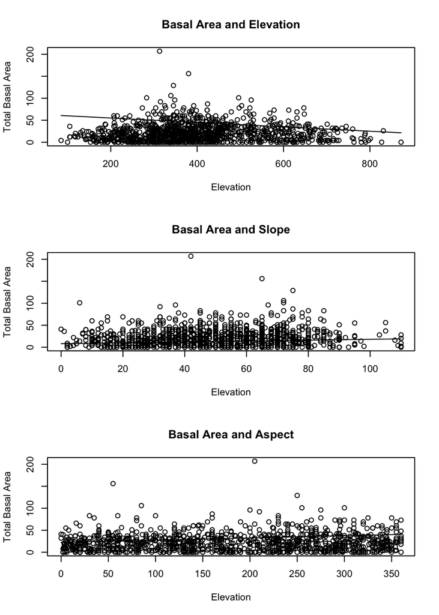

```r
# Create scatterplots of all three terrain variables and total basal area into one plot and fit a linear function to each terrain variable.
# First make the line
line_point_slope = function(x, x1, y1, slope)
{
  get_y_intercept =
    function(x1, y1, slope)
      return(-(x1 * slope) + y1)

  linear =
    function(x, yint, slope)
      return(yint + x * slope)

  return(linear(x, get_y_intercept(x1, y1, slope), slope))
}
par(mfrow = c(3, 1))
plot(dat_habitat$elev, dat_habitat$ba.tot, main = "Basal Area and Elevation",
     xlab = "Elevation", ylab = "Total Basal Area")
curve(line_point_slope(x, x1 = 400, y1 = 45, slope = -0.05), add = TRUE)

plot(dat_habitat$slope, dat_habitat$ba.tot, main = "Basal Area and Slope",
     xlab = "Elevation", ylab = "Total Basal Area")
curve(line_point_slope(x, x1 = 20, y1 = 10, slope = 0.1), add = TRUE)

plot(dat_habitat$aspect, dat_habitat$ba.tot, main = "Basal Area and Aspect",
     xlab = "Elevation", ylab = "Total Basal Area")
curve(line_point_slope(x, x1 = 50, y1 = 25, slope = 0.05), add = TRUE)
```

### Q8

**For each terrain variable (elevation, slope, aspect), describe the relationship you observe and your model fit.**

For elevation, there does seem to be some association between total basal area and elevation. Total basal area tends to increase as elevation increases, but then reaches a peak and starts to decrease around 400 meters, and is slightly skewed towards lower elevations. While there could be a relationship, it isn’t linear but more of a quadratic association. Because of this, a linear model is not a good fit for this data.

For slope, there may be an association, given that the density of our data points starts to decrease right around 80 percent slope. However, the association is definitely not linear and a linear model is not a good fit for this data.

For aspect, there does not seem to be any association between the two variables. Since there is no visible association, it is not a linear relationship and a linear model does not work for these particular variables.